# Projet GMM5 2017

Nathalie Villa-Vialaneix, Gicu Stratan and Soizick Magon de La Giclais

10 décembre, 2017

This files is a summary of the work made by GMM5 students on data coming from ENVT study.

The data are processed using the following packages:

```r
library(mixOmics)
library(metagenomeSeq)
library(reshape2)
```

# Data description

Data are given in two files included in the directory `data` :

- the first one is the file `abondances.csv` that contains microbiote data:

```r
df_abundances <- read.delim("../data/abondances.csv", sep = ",",
                            stringsAsFactors = FALSE)
summary(df_abundances[ ,1:15])
```

```
##  X.blast_taxonomy   blast_subject      blast_perc_identity
##  Length:406         Length:406         Min.   : 94.18
##  Class :character   Class :character   1st Qu.: 99.39
##  Mode  :character   Mode  :character   Median : 99.80
##                                        Mean   : 99.32
##                                        3rd Qu.:100.00
##                                        Max.   :100.00
##  blast_perc_query_coverage  blast_evalue blast_aln_length
##  Min.   : 98.13            Min.   :0     Min.   :430.0
##  1st Qu.:100.00            1st Qu.:0     1st Qu.:466.2
##  Median :100.00            Median :0     Median :480.0
##  Mean   : 99.96            Mean   :0     Mean   :477.4
##  3rd Qu.:100.00            3rd Qu.:0     3rd Qu.:490.0
##  Max.   :100.00            Max.   :0     Max.   :512.0
##    seed_id          observation_name   observation_sum
##  Length:406         Length:406         Min.   :   224.0
##  Class :character   Class :character   1st Qu.:   588.5
##  Mode  :character   Mode  :character   Median :   979.5
##                                        Mean   :  9753.7
##                                        3rd Qu.:  2738.0
##                                        Max.   :880523.0
##  NG.10214_EN10A_lib136338_4869_1 NG.10214_EN10B_lib136339_4869_1
##  Min.   :    0.0                 Min.   :    0.0
##  1st Qu.:    0.0                 1st Qu.:    0.0
##  Median :    0.0                 Median :    0.0
##  Mean   :  108.4                 Mean   :  108.4
##  3rd Qu.:   12.0                 3rd Qu.:   12.0
##  Max.   :17044.0                 Max.   :17663.0
##  NG.10214_EN11A_lib136340_4869_1 NG.10214_EN11B_lib136341_4869_1
##  Min.   :    0.0                 Min.   :    0.0
##  1st Qu.:    0.0                 1st Qu.:    0.0
##  Median :    1.0                 Median :    1.0
##  Mean   :  108.4                 Mean   :  108.4
##  3rd Qu.:    6.0                 3rd Qu.:    6.0
##  Max.   :24223.0                 Max.   :23739.0
##  NG.10214_EN15A_lib136342_4869_1 NG.10214_EN15B_lib136343_4869_1
##  Min.   :    0.00                Min.   :    0.00
##  1st Qu.:    0.00                1st Qu.:    0.00
##  Median :    3.00                Median :    4.00
##  Mean   :  108.37                Mean   :  108.37
##  3rd Qu.:   15.75                3rd Qu.:   15.75
##  Max.   :28421.00                Max.   :27946.00
```

The first 9 columns contain information about the different bacteria identified within samples. The following columns contain the two technical replicates (identified by “A” and “B”) of all the farms involved in the study (the farm is identified by a number preceeding the letter “A”/“B”).

Note that some “blast taxonomy” are duplicated:

```r
unique(names(which(table(df_abundances[ ,1]) > 1)))
```

```
##  [1] "Bacteria;Actinobacteria;Actinobacteria;Corynebacteriales;Corynebacteriaceae;Corynebacterium 1;Corynebacterium sp."
##  [2] "Bacteria;Actinobacteria;Actinobacteria;Corynebacteriales;Corynebacteriaceae;Corynebacterium 1;unknown species"
##  [3] "Bacteria;Actinobacteria;Actinobacteria;Corynebacteriales;Corynebacteriaceae;Corynebacterium;unknown species"
##  [4] "Bacteria;Actinobacteria;Actinobacteria;Corynebacteriales;Dietziaceae;Dietzia;Dietzia sp."
##  [5] "Bacteria;Actinobacteria;Actinobacteria;Corynebacteriales;Nocardiaceae;Rhodococcus;Rhodococcus sp."
##  [6] "Bacteria;Actinobacteria;Actinobacteria;Micrococcales;Brevibacteriaceae;Brevibacterium;Brevibacterium antiquum"
##  [7] "Bacteria;Actinobacteria;Actinobacteria;Micrococcales;Brevibacteriaceae;Brevibacterium;unknown species"
##  [8] "Bacteria;Actinobacteria;Actinobacteria;Micrococcales;Intrasporangiaceae;Janibacter;unknown species"
##  [9] "Bacteria;Actinobacteria;Actinobacteria;Micrococcales;Microbacteriaceae;Leucobacter;unknown species"
## [10] "Bacteria;Actinobacteria;Actinobacteria;Micrococcales;Micrococcaceae;Arthrobacter;Arthrobacter sp."
## [11] "Bacteria;Actinobacteria;Actinobacteria;Streptomycetales;Streptomycetaceae;Streptomyces;Streptomyces sp."
## [12] "Bacteria;Bacteroidetes;Bacteroidia;Bacteroidales;Bacteroidaceae;Bacteroides;unknown species"
## [13] "Bacteria;Bacteroidetes;Bacteroidia;Bacteroidales;Porphyromonadaceae;Petrimonas;unknown species"
## [14] "Bacteria;Bacteroidetes;Bacteroidia;Bacteroidales;Porphyromonadaceae;Porphyromonas;unknown species"
## [15] "Bacteria;Bacteroidetes;Bacteroidia;Bacteroidales;Porphyromonadaceae;Proteiniphilum;unknown species"
```

[output cut: 46 more lines]

as well as some of the bast id themselves

```r
unique(names(which(table(df_abundances[ ,2]) > 1)))
```

```
##  [1] "AB680687.1.1434" "AB681778.1.1454" "AF224286.1.1534"
##  [4] "AJ491302.1.1509" "AM183097.1.1441" "AY243344.1.1501"
##  [7] "AY725811.1.1474" "FJ672272.1.1408" "FJ674571.1.1375"
## [10] "FJ674662.1.1457" "GQ358834.1.1513" "GQ358846.1.1455"
## [13] "HM325988.1.1341" "HM327870.1.1341" "JX986968.1.1511"
## [16] "KC894531.1.1498"
```

# Microbiote analysis

## Preprocessing and normalization

First, the two technical replicates are merged (simple sums as the counts have already been normalized to identical library sizes)

```r
abundances <- df_abundances[ ,grep("A_", colnames(df_abundances))] +
  df_abundances[ ,grep("B_", colnames(df_abundances))]
dim(abundances)
```

```
## [1] 406  45
```

which leads to 45 samples (columns) in which 406 bacteria have been observed (rows).

Condition (“EN” or “LBA”) is extracted from column names:

```r
condition <- rep("LBA", ncol(abundances))
condition[grep("EN", colnames(abundances))] <- "EN"
condition <- factor(condition)
table(condition)
```

```
## condition
##  EN LBA
##  22  23
```

Also, the farm identifier is extracted from column names:

```r
id_abundances <- as.character(colnames(abundances))
id_abundances <- sapply(id_abundances, function(ac)
  substr(ac, nchar(ac) - 19, nchar(ac) - 18))
id_abundances <- gsub("A", "0", id_abundances)
id_abundances <- gsub("N", "0", id_abundances)
table(id_abundances)
```

```
## id_abundances
## 01 03 04 06 07 09 10 11 15 16 17 18 19 20 21 23 24 25 26 28 29 30 31
##  2  2  2  2  2  2  2  2  2  2  2  2  2  2  2  2  2  2  2  2  1  2  2
```

All but one farm (idenfier: 29) have been sampled twice, once for each condition.

## Merging duplicates

Duplicated species (based on identical taxonomies) are then merged (counts are summed). To do so, first simplified species names are obtained (last unknown species for every row):

```r
species <- sapply(df_abundances[ ,1], function(aname)
  unlist(strsplit(aname, ";")))
species <- sapply(species, function(avect) {
  find_unknown <- grep("unknown", avect)
  if (length(find_unknown) > 0) {
    return(avect[-find_unknown])
  } else return(avect)
})
species <- unlist(sapply(species, function(avect) avect[length(avect)]))
species <- unname(species)
```

Then, counts corresponding to the same simplified name are summed:

```r
abundances <- apply(abundances, 2, function(acol) tapply(acol, species, sum))
```

and the species names are retrieved:

```r
species <- rownames(abundances)
```

One species has an unexpected name:

```r
head(species)
```

```
## [1] "&"
## [2] "[Eubacterium] coprostanoligenes group"
## [3] "[Ruminococcus] gauvreauii group"
## [4] "Acetobacteraceae bacterium SAP1007.2"
## [5] "Acholeplasma laidlawii PG-8A"
## [6] "Achromobacter sp."
```

that corresponds to the row number 73 in the original data (checked also directly in the file sent by Elias on 10/09).

## Exploratory analysis: distribution of one sample

The effect of different normalization is first explored by analyzing the distributions of the counts in the first sample before and after normalization. Distribution before normalization is provided as:

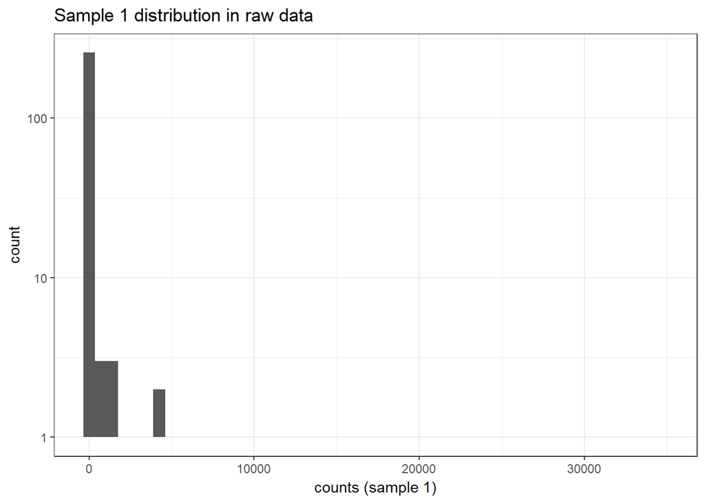

```r
df <- data.frame(abundances)
names(df) <- paste0("sample", 1:ncol(df))
ggplot(df, aes(x = sample1 +1)) + geom_histogram(bins = 50) + scale_y_log10() +
  theme_bw() + xlab("counts (sample 1)") + ggtitle("Sample 1 distribution in raw data")
```

and with a log-transformation by

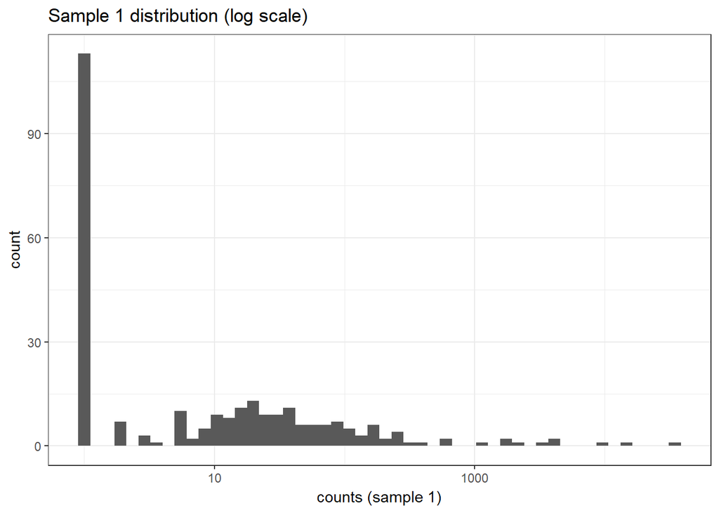

```r
ggplot(df, aes(x = sample1 + 1)) + geom_histogram(bins = 50) +
  theme_bw() + xlab("counts (sample 1)") + scale_x_log10() +
  ggtitle("Sample 1 distribution (log scale)")
```

It is commun in metagenomic datasets to perform TSS (*Total Sum Scaling*) before further normalization. TSS transformation computes relative abundances:
$$y_{ij} = \frac{n_{ij}}{\sum_{k=1}^p n_{ik}}$$
for $n_{ij}$ the counts of species $j$ in sample $i$, $p$ the number of species and $n$ the number of individuals.

```r
abundances_TSS <- apply(abundances, 1, function(asample)  asample / sum(asample))
df <- as.data.frame(t(abundances_TSS))
names(df) <- paste0("sample", 1:ncol(df))
dim(df)
```

```
## [1] 270  45
```

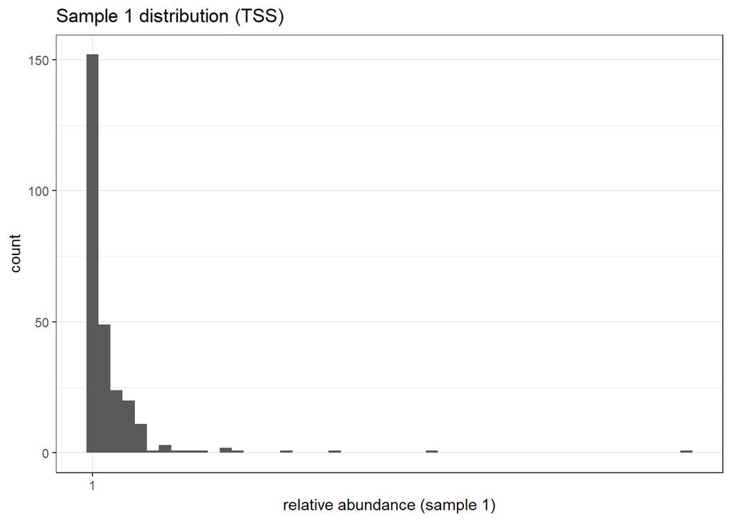

```r
ggplot(df, aes(x = sample1 + 1)) + geom_histogram(bins = 50) +
  theme_bw() + xlab("relative abundance (sample 1)") + scale_x_log10() + ggtitle("Sample 1 distribution (TSS)")
```

The next two histograms are based on the normalized counts with:

- CLR (*Centered Log Ratio*) transformation:
  $$\tilde{y}_{ij} = \log \frac{y_{ij}}{\sqrt[p]{\prod_{k=1}^p y_{ik}}}.$$

```r
abundances_CLR <- logratio.transfo(abundances_TSS, logratio = "CLR",
                                   offset = 1)
class(abundances_CLR) <- "matrix"
df <- data.frame(t(abundances_CLR))
names(df) <- paste0("sample", 1:ncol(df))
dim(df)
```

```
## [1] 270  45
```

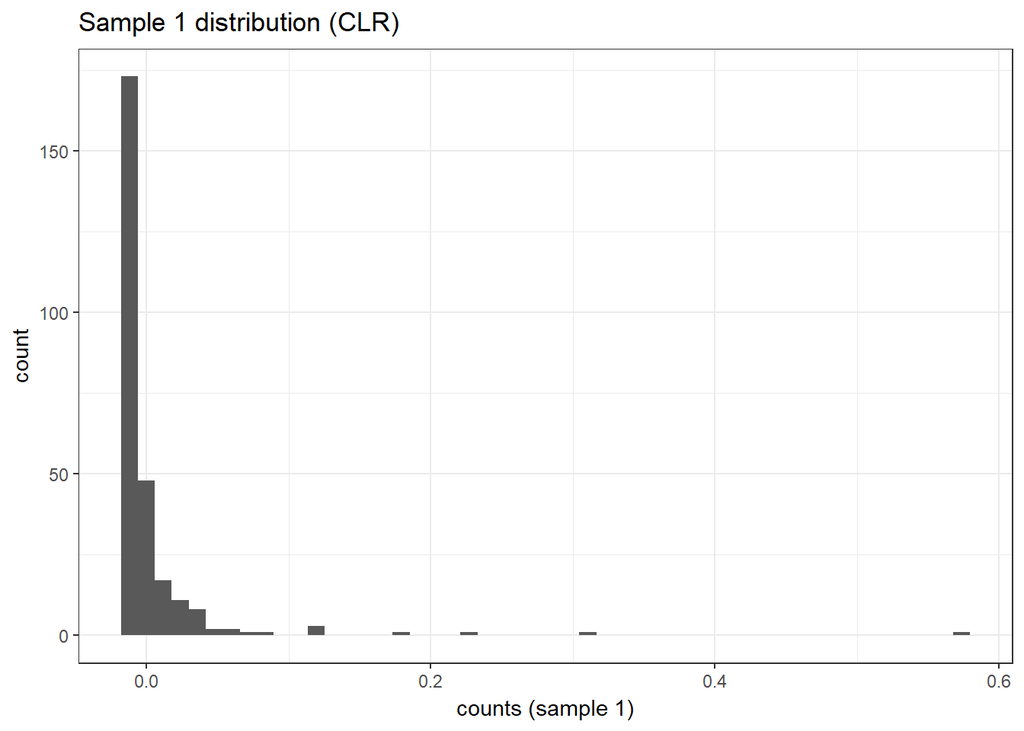

```r
ggplot(df, aes(x = sample1)) + geom_histogram(bins = 50) + theme_bw() +
  xlab("counts (sample 1)") + ggtitle("Sample 1 distribution (CLR)")
```

- ILR (*Isometric Log Ratio*) transformation
  $$\tilde{\mathbf{Y}}' = \tilde{\mathbf{Y}} \times \mathbf{V}$$
  for $\tilde{\mathbf{Y}}$ the matrix of CLR transformed data and a given matrix $\mathbf{V}$ with $p$ rows and $p-1$ columns such that $\mathbf{V} \mathbf{V}^\top = \mathbb{I}_{p-1}$ and $\mathbf{V}^\top \mathbf{V} = \mathbb{I} + a \mathbf{1}$, $a$ being any positive number and $\mathbf{1}$ a vector full of 1.

```r
abundances_ILR <- logratio.transfo(abundances_TSS, logratio = "ILR",
                                   offset = 1)
class(abundances_ILR) <- "matrix"
df <- data.frame(t(abundances_ILR))
names(df) <- paste0("sample", 1:ncol(df))
dim(df)
```

```
## [1] 269  45
```

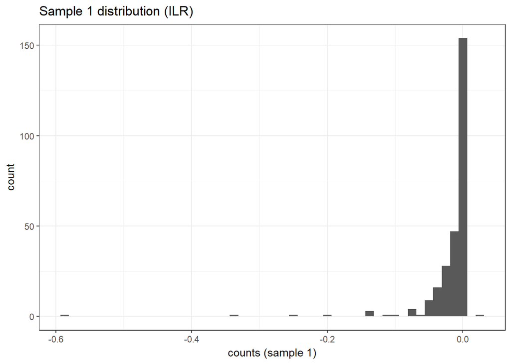

```r
ggplot(df, aes(x = sample1)) + geom_histogram(bins = 50) + theme_bw() +
  xlab("counts (sample 1)") + ggtitle("Sample 1 distribution (ILR)")
```

- CSS transformation, which is an adaptative extension for metagenomic data of the quantile normalization used in microarray expression datasets. It is designed so as to account for technical differences between samples.

```r
abundances_CSS <- newMRexperiment(abundances)
abundances_CSS <- cumNorm(abundances_CSS)
```

```
## Default value being used.
```

```r
df <- data.frame(MRcounts(abundances_CSS))
names(df) <- paste0("sample", 1:ncol(df))
dim(df)
```

```
## [1] 270  45
```

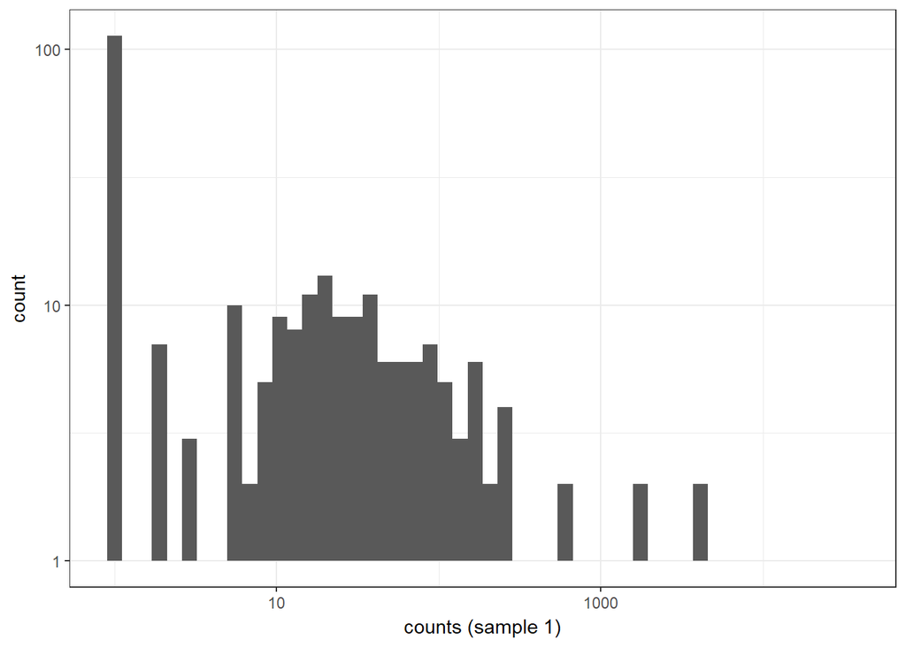

```r
ggplot(df, aes(x = sample1 + 1)) + geom_histogram(bins = 50) + theme_bw() +
  xlab("counts (sample 1)") + scale_y_log10() + scale_x_log10()
```

## Exploratory analysis: distribution of all samples

Distributions of all samples according to the type of transformation and the sample is provided below:

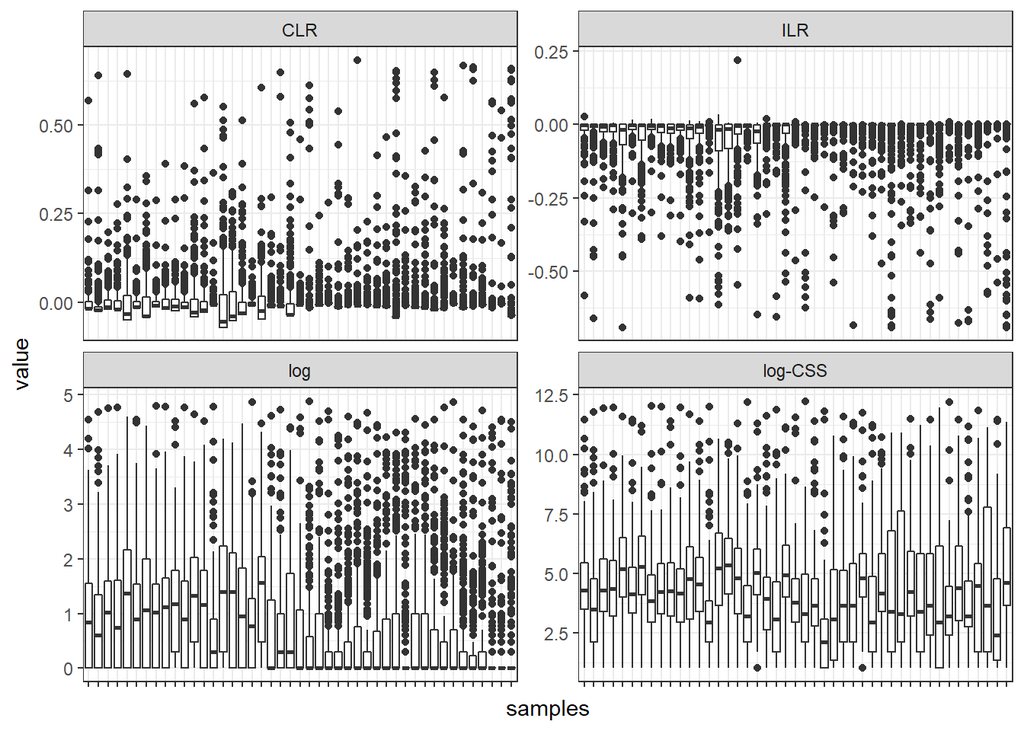

```r
df_log <- log10(abundances + 1)
df_log <- data.frame(df_log)
rownames(df_log) <- NULL
names(df_log) <- paste0("Sample", 1:ncol(df_log))
df_log <- melt(df_log)
df_CLR <- data.frame(t(abundances_CLR))
names(df_CLR) <- paste0("Sample", 1:ncol(df_CLR))
df_CLR <- melt(df_CLR)
df_ILR <- data.frame(t(abundances_ILR))
names(df_ILR) <- paste0("Sample", 1:ncol(df_ILR))
df_ILR <- melt(df_ILR)
df_CSS <- data.frame(log(MRcounts(abundances_CSS)) + 1)
names(df_CSS) <- paste0("Sample", 1:ncol(df_CSS))
df_CSS <- melt(df_CSS)
all_sizes <- c(nrow(df_log), nrow(df_CLR), nrow(df_ILR), nrow(df_CSS))
df <- data.frame(rbind(df_log, df_CLR, df_ILR, df_CSS),
                 "type" = rep(c("log", "CLR", "ILR", "log-CSS"), all_sizes))
ggplot(df, aes(x = variable, y = value)) + geom_boxplot() + theme_bw() +
  facet_wrap(~ type, scales = "free_y") + xlab("samples") +
  theme(axis.text.x = element_blank())
```

## Exploratory analysis: PCA

**Log**

A first exploratory analysis is performed with PCA on (merged) raw counts with log transformation:

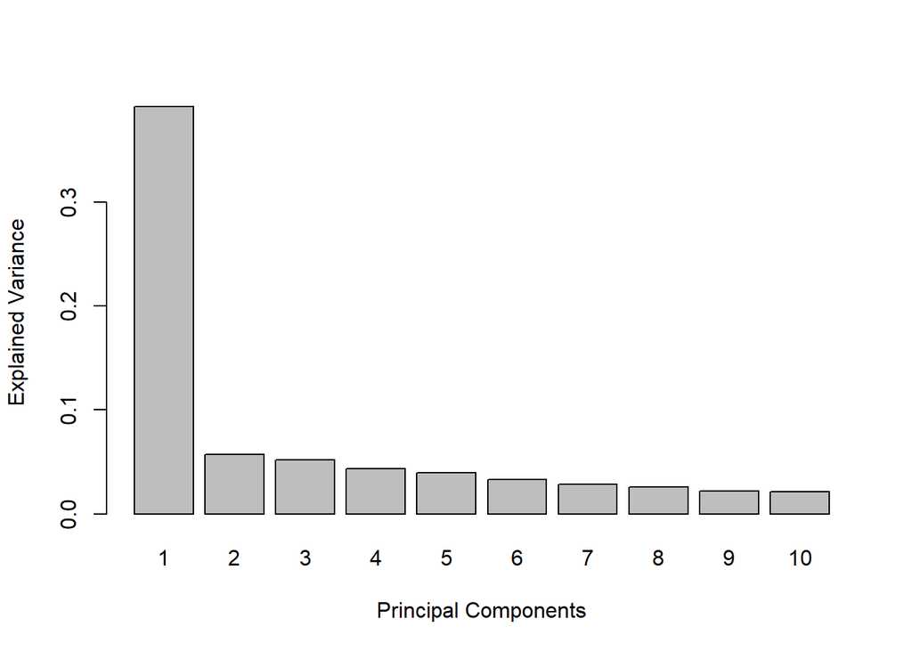

```r
pca_raw <- pca(log(t(abundances) + 1), ncomp = ncol(abundances),
               logratio = 'none')
plot(pca_raw)
```

that shows a good percentage of explained variance for the first axis.

Projection of the individuals on the first two PCs also shows a good separation between the two conditions:

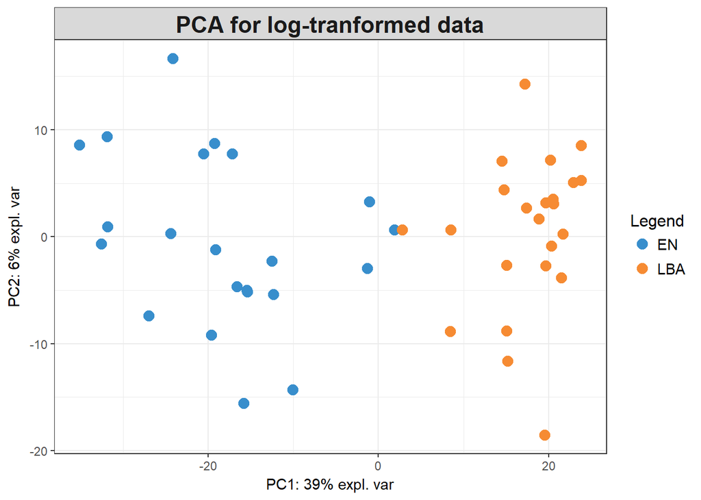

```r
plotIndiv(pca_raw,
          comp = c(1,2),
          pch = 16,
          ind.names = FALSE,
          group = condition,
          col.per.group = color.mixo(1:2),
          legend = TRUE,
          title="PCA for log-tranformed data")
```

**TSS+CLR**

The same analysis is used with TSS normalized counts subsequently transformed by CLR or ILR (which is the expected analysis):

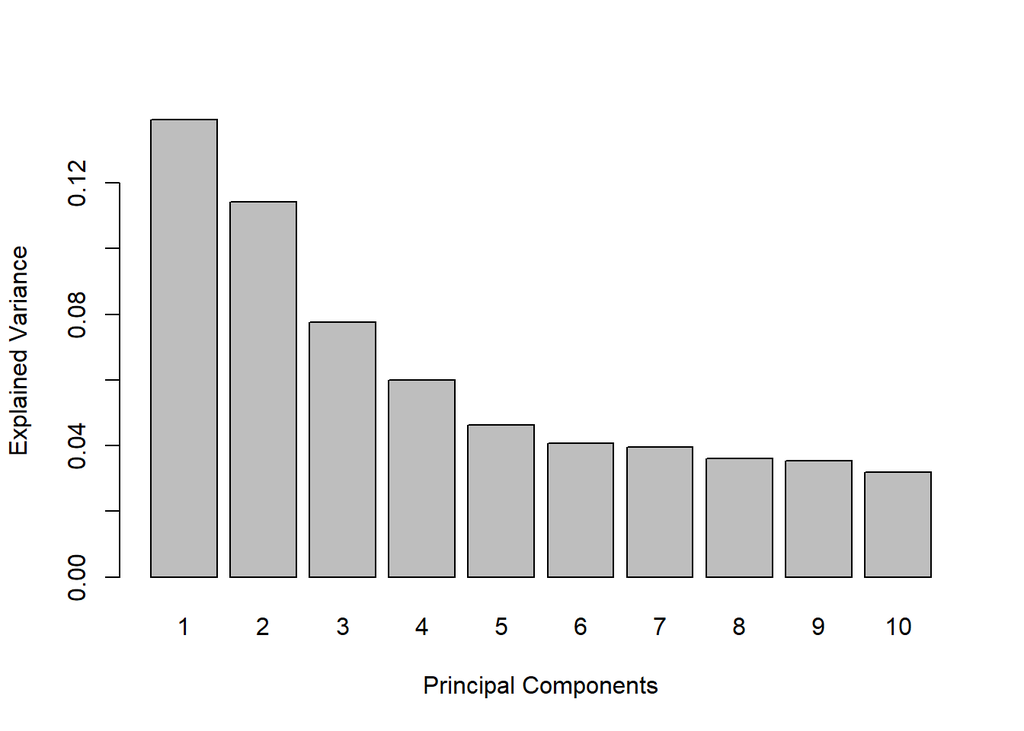

```r
pca_CLR <- pca(abundances_TSS + 1, ncomp = nrow(abundances_TSS),
               logratio = 'CLR')
plot(pca_CLR)
```

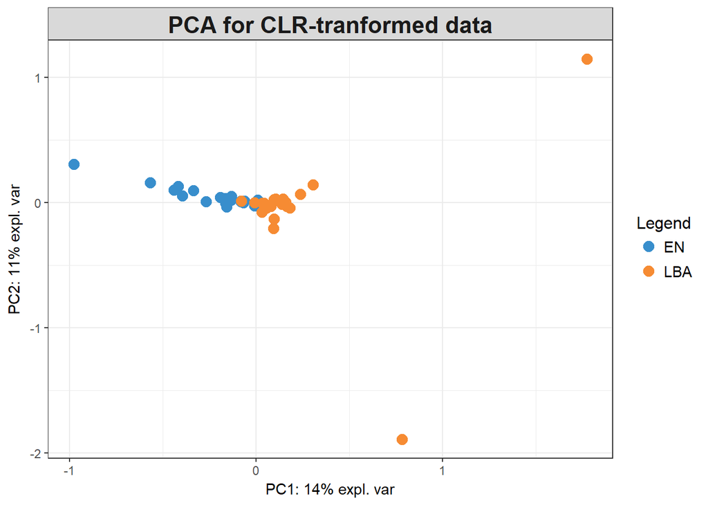

```r
plotIndiv(pca_CLR,
          comp = c(1,2),
          pch = 16,
          ind.names = FALSE,
          group = condition,
          col.per.group = color.mixo(1:2),
          legend = TRUE,
          title="PCA for CLR-tranformed data")
```

**TSS+ILR**

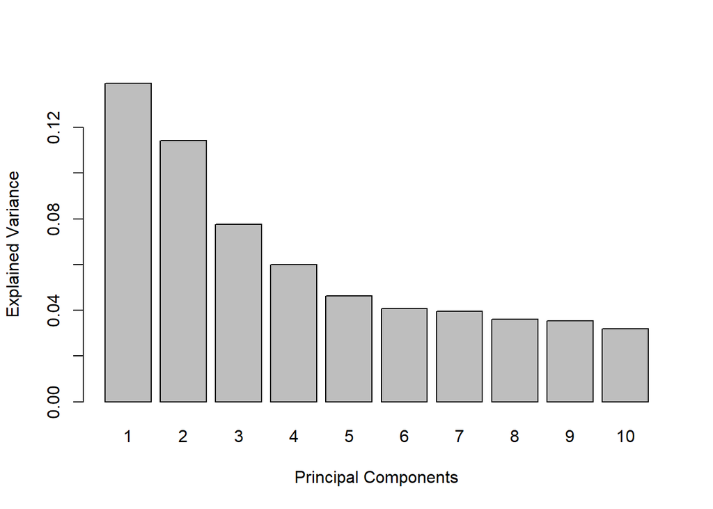

```r
pca_ILR <- pca(abundances_TSS + 1, ncomp = nrow(abundances_TSS) - 1,
               logratio = 'ILR')
plot(pca_ILR)
```

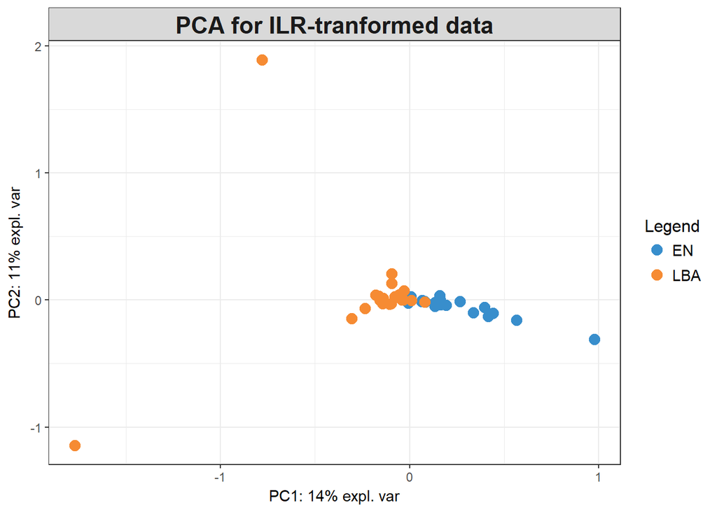

```r
plotIndiv(pca_ILR,
          comp = c(1,2),
          pch = 16,
          ind.names = FALSE,
          group = condition,
          col.per.group = color.mixo(1:2),
          legend = TRUE,
          title="PCA for ILR-tranformed data")
```

**CSS**

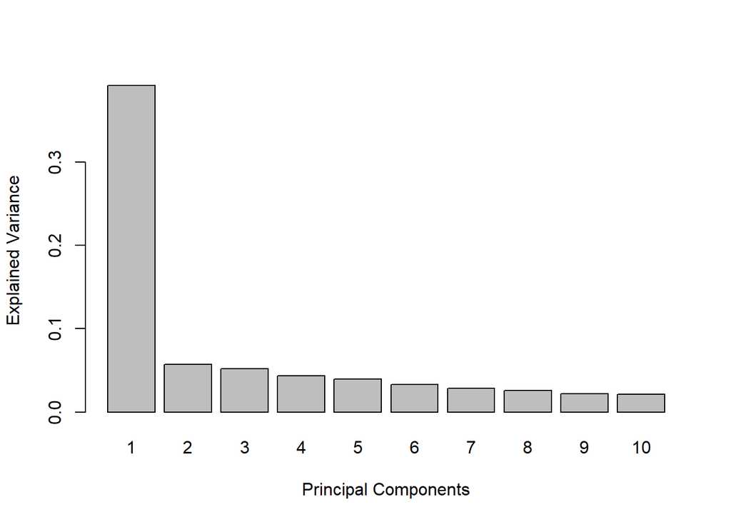

```r
log_CSS <- log(MRcounts(abundances_CSS) + 1)
pca_CSS <- pca(t(log_CSS), ncomp = ncol(log_CSS))
plot(pca_CSS)
```

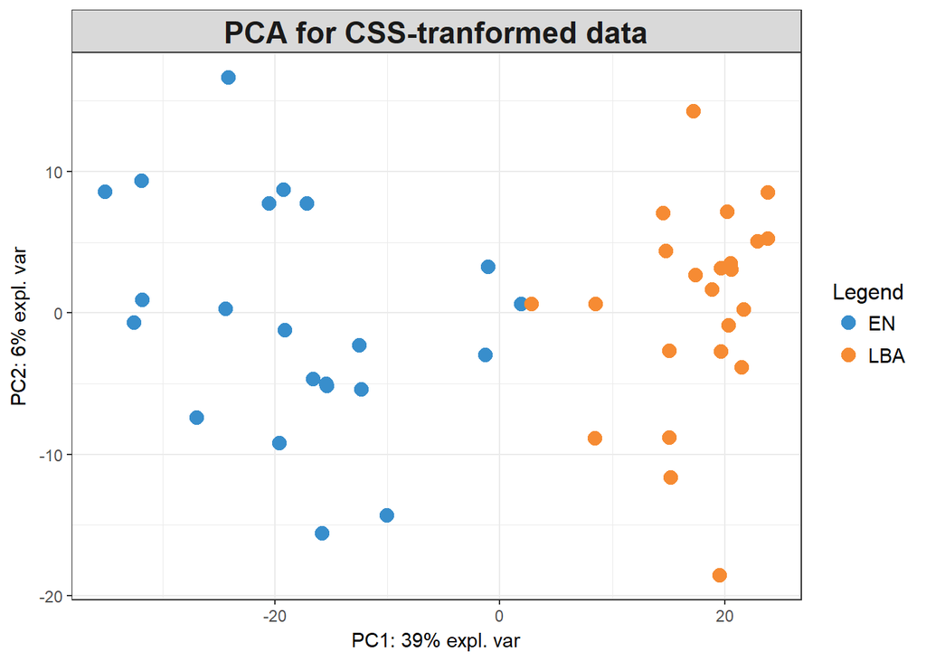

```r
plotIndiv(pca_CSS,
          comp = c(1,2),
          pch = 16,
          ind.names = FALSE,
          group = condition,
          col.per.group = color.mixo(1:2),
          legend = TRUE,
          title="PCA for CSS-tranformed data")
```

## Differences between the two types of samples

### with log transformation

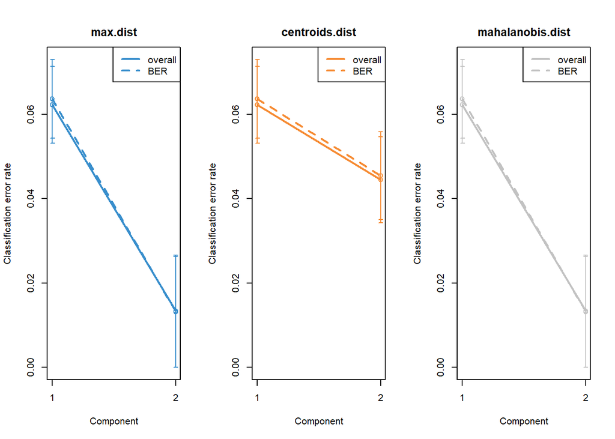

```r
set.seed(11)
res_plsda <- plsda(log(t(abundances)+1), condition, ncomp = nlevels(condition))
res_perf <- perf(res_plsda, validation = 'Mfold', folds = 5,
                  progressBar = FALSE, nrepeat = 20)
plot(res_perf, overlay = 'measure', sd = TRUE)
```

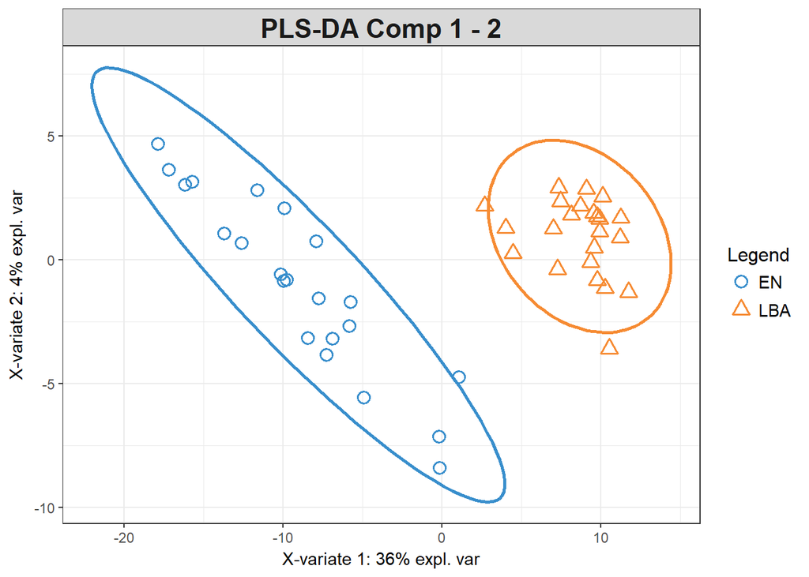

```r
plotIndiv(res_plsda , comp = c(1, 2), ind.names = FALSE, ellipse = TRUE,
          legend = TRUE, title = 'PLS-DA Comp 1 - 2')
```

PLS-DA shows a good separation between the two groups and indicates that the Mahalanobis distance provides the lower overall classification error.

**Creation of data set log transformed and without the calf 29:**

```r
clean_log <- data.frame(log(t(abundances[ ,id_abundances != "29"]) + 1))
names(clean_log) <- species
clean_condition <- factor(condition[id_abundances != "29"])
clean_id <- factor(id_abundances[id_abundances != "29"])
```

```r
set.seed(33)
res_plsda <- tune.splsda(clean_log, clean_condition,
                         ncomp = nlevels(clean_condition),
                         multilevel = clean_id,
                         test.keepX = 1:20, validation = 'Mfold', folds = 10,
                         dist = 'mahalanobis.dist', nrepeat = 10,
                         progressBar = FALSE)
```

```
## Splitting the variation for 1 level factor.
```

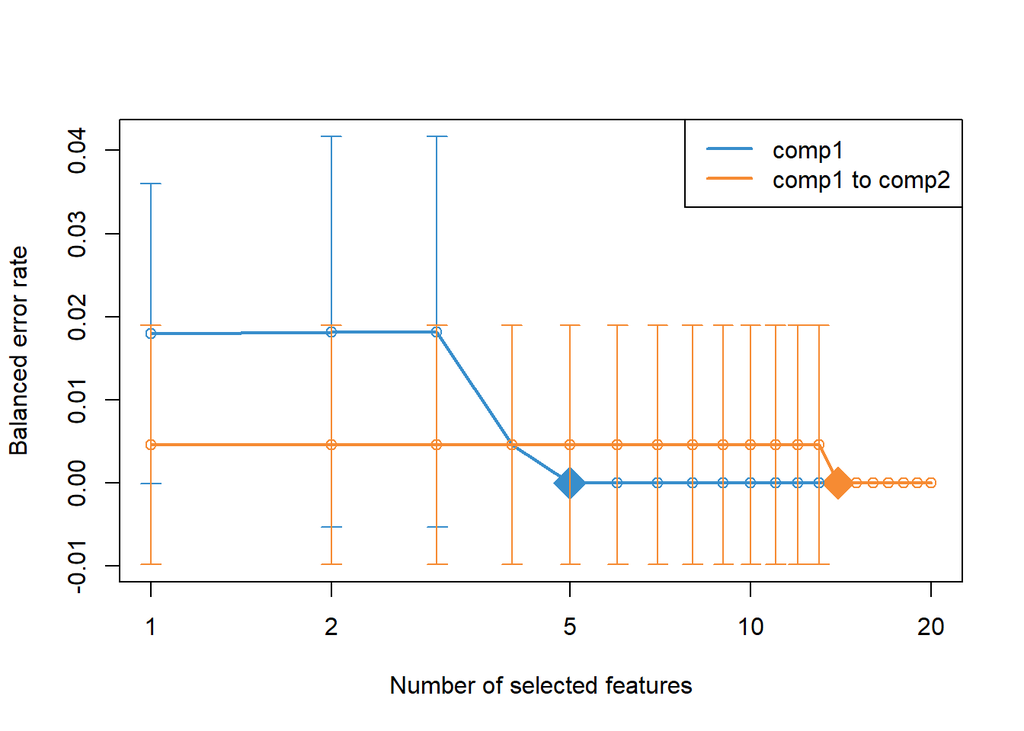

```r
plot(res_plsda)
```

```r
sel_keepX <- res_plsda$choice.keepX[1:2]
sel_keepX
```

```
## comp1 comp2
##     5    14
```

Finally sparse PLS-DA is performed and the variables explaining the two types of samples are obtained:

```r
res_splsda <- splsda(clean_log, clean_condition,
                     ncomp = nlevels(clean_condition), multilevel = clean_id,
                     keepX = sel_keepX)
```

```
## Splitting the variation for 1 level factor.
```

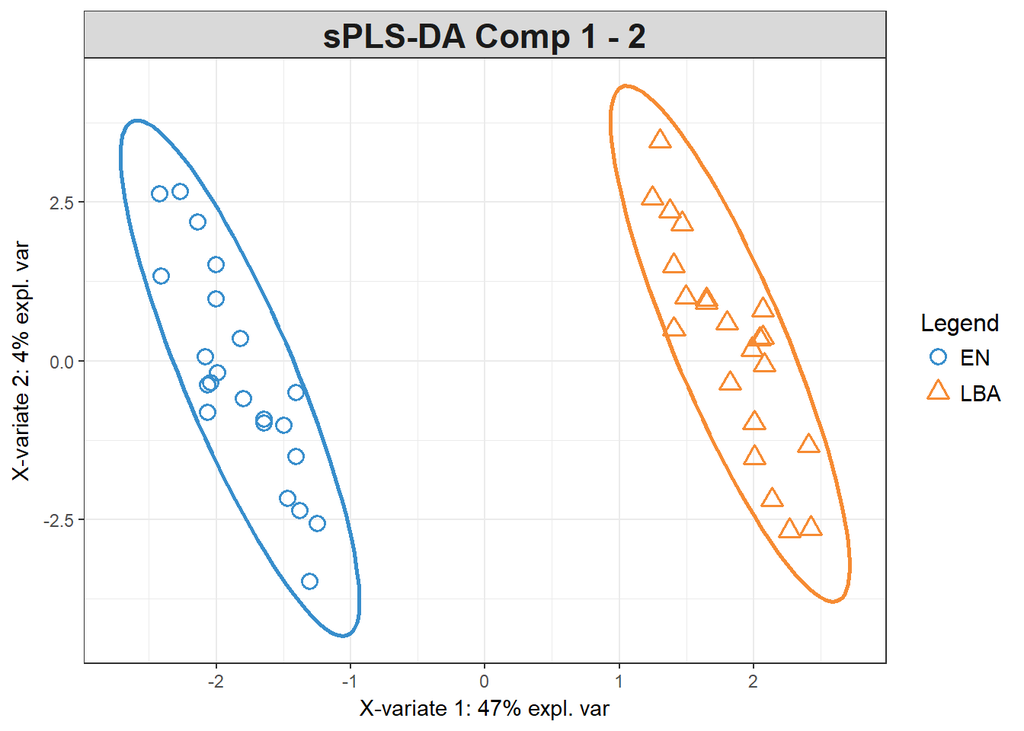

```r
plotIndiv(res_splsda, comp = c(1,2), ind.names = FALSE, ellipse = TRUE,
          legend = TRUE, title = 'sPLS-DA Comp 1 - 2')
```

```r
head(selectVar(res_splsda, comp = 1)$name)
```

```
## [1] "Mycoplasma bovoculi M165/69"    "Corynebacterium camporealensis"
## [3] "Moraxella"                      "Aquamicrobium"
## [5] "Peptoclostridium"
```

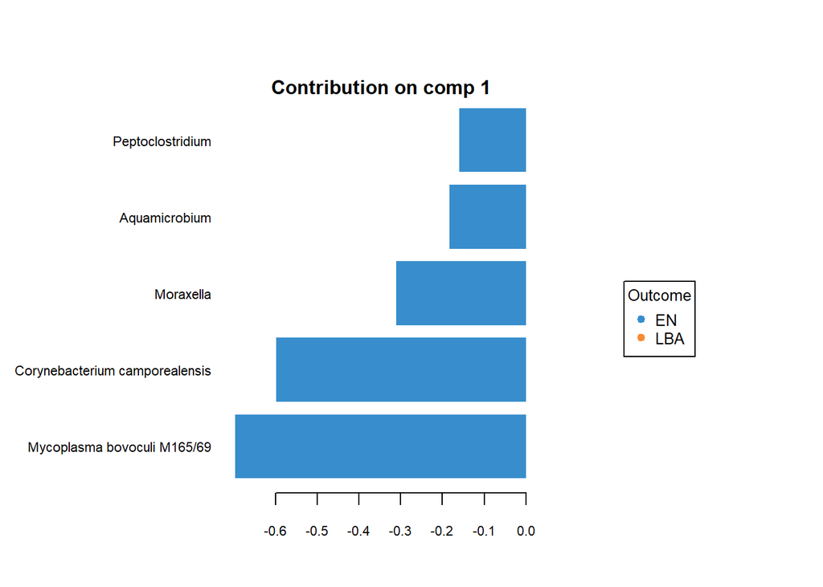

```r
plotLoadings(res_splsda, comp = 1, method = 'mean', contrib = 'max',
             size.title = 1)
```

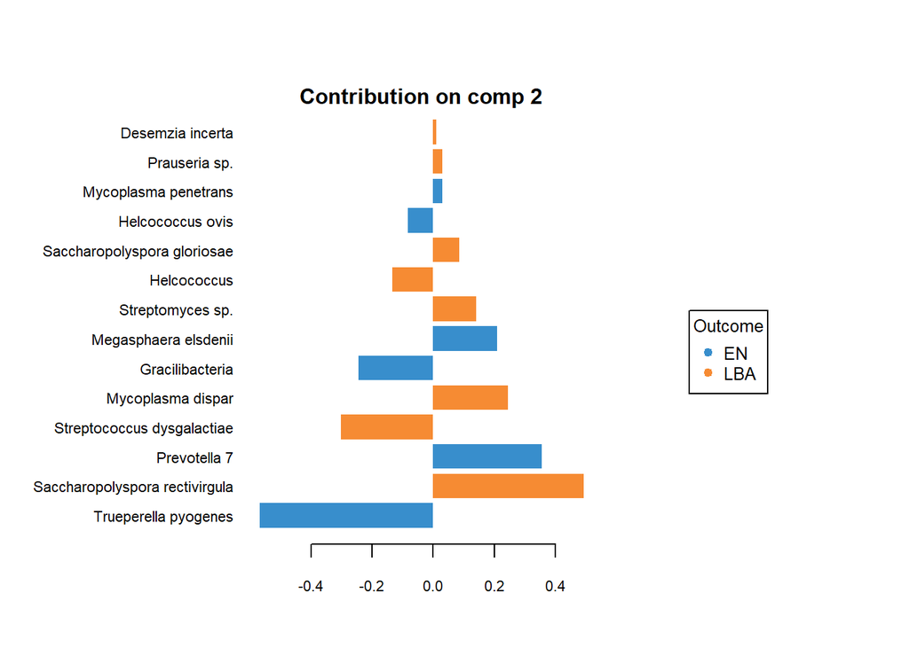

```r
plotLoadings(res_splsda, comp = 2, method = 'mean', contrib = 'max',
             size.title = 1)
```

**EN vs LBA: Student test on selected Variables**

```r
cat("Selected variables:",paste(selectVar(res_splsda, comp = 1)$name,collapse=', '))
```

```
## Selected variables: Mycoplasma bovoculi M165/69, Corynebacterium camporealensis, Moraxella, Aquamicrobium, Peptoclostridium
```

```r
testEN <- clean_log[clean_condition=="EN",grep(selectVar(res_splsda, comp = 1)$name[1],species)]
testLBA <- clean_log[clean_condition=="LBA",grep(selectVar(res_splsda, comp = 1)$name[1],species)]
t.test(testEN,testLBA,paired=TRUE)
```

```
##
##  Paired t-test
##
## data:  testEN and testLBA
## t = 14.059, df = 21, p-value = 3.728e-12
## alternative hypothesis: true difference in means is not equal to 0
## 95 percent confidence interval:
##  4.717008 6.354767
## sample estimates:
## mean of the differences
##                5.535887
```

We reject $H_0$ (the difference in means is equal to 0) hence we can say that there is a difference between the two types of samples (EN and LBA) for the Mycoplasma bovoculi M165/69 bateria.

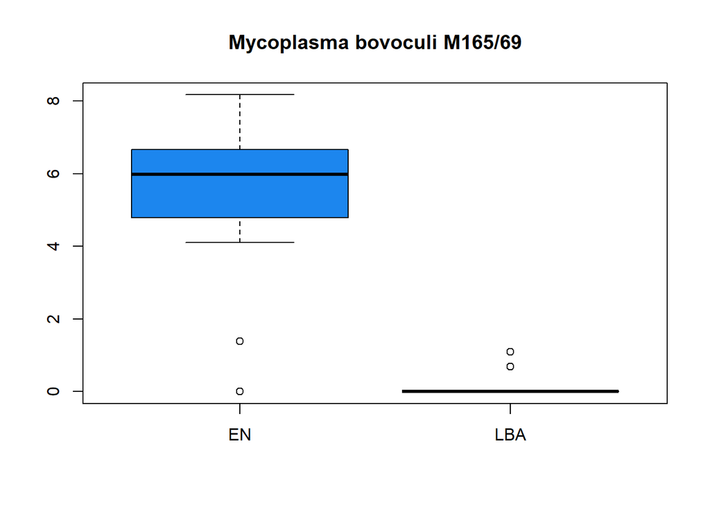

```r
boxplot(testEN,testLBA,names=c("EN","LBA"),
        main=selectVar(res_splsda, comp = 1)$name[1],col=c("dodgerblue2","darkorange"))
```

```r
testEN <- clean_log[clean_condition=="EN",grep(selectVar(res_splsda, comp = 1)$name[2],species)]
testLBA <- clean_log[clean_condition=="LBA",grep(selectVar(res_splsda, comp = 1)$name[2],species)]
t.test(testEN,testLBA,paired=TRUE)
```

```
##
##  Paired t-test
##
## data:  testEN and testLBA
## t = 13.686, df = 21, p-value = 6.214e-12
## alternative hypothesis: true difference in means is not equal to 0
## 95 percent confidence interval:
##  2.967682 4.031138
## sample estimates:
## mean of the differences
##                 3.49941
```

We reject $H_0$ (the difference in means is equal to 0) hence we can say that there is a difference between the two types of samples (EN and LBA) for the Corynebacterium camporealensis bateria.

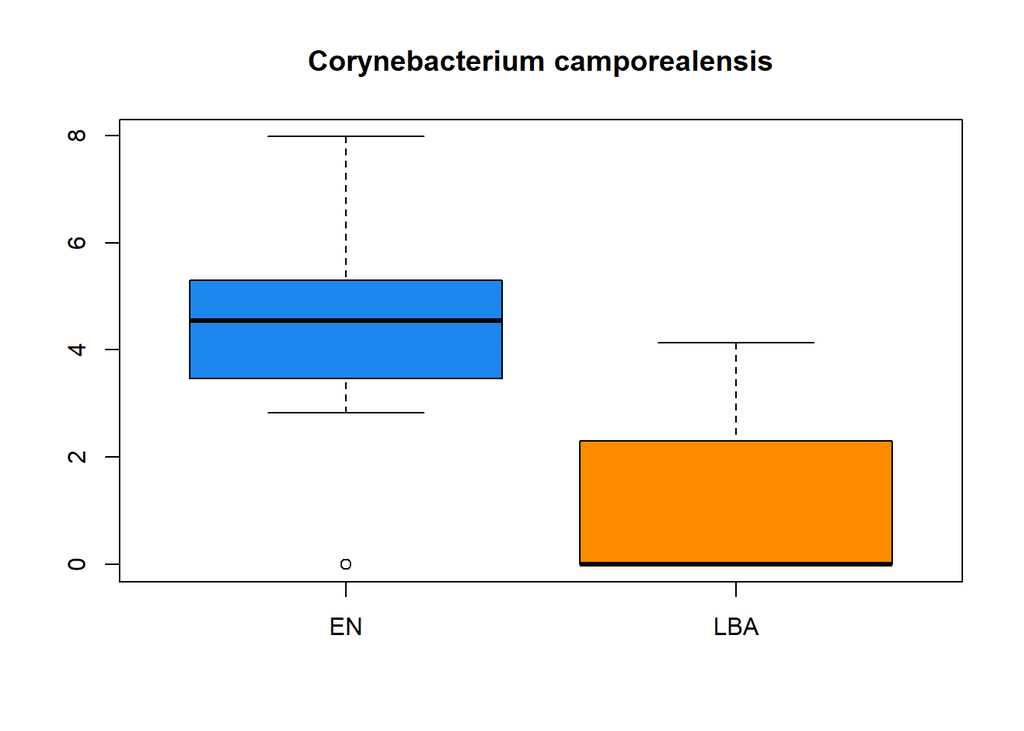

```r
boxplot(testEN,testLBA,names=c("EN","LBA"),
        main=selectVar(res_splsda, comp = 1)$name[2],col=c("dodgerblue2","darkorange"))
```

```r
testEN <- clean_log[clean_condition=="EN",which(selectVar(res_splsda, comp = 1)$name[3]==species)]
testLBA <- clean_log[clean_condition=="LBA",which(selectVar(res_splsda, comp = 1)$name[3]==species)]
t.test(testEN,testLBA,paired=TRUE)
```

```
##
##  Paired t-test
##
## data:  testEN and testLBA
## t = 12.748, df = 21, p-value = 2.368e-11
## alternative hypothesis: true difference in means is not equal to 0
## 95 percent confidence interval:
##  4.617779 6.418044
## sample estimates:
## mean of the differences
##                5.517911
```

We reject $H_0$ (the difference in means is equal to 0) hence we can say that there is a difference between the two types of samples (EN and LBA) for the Moraxella bateria.

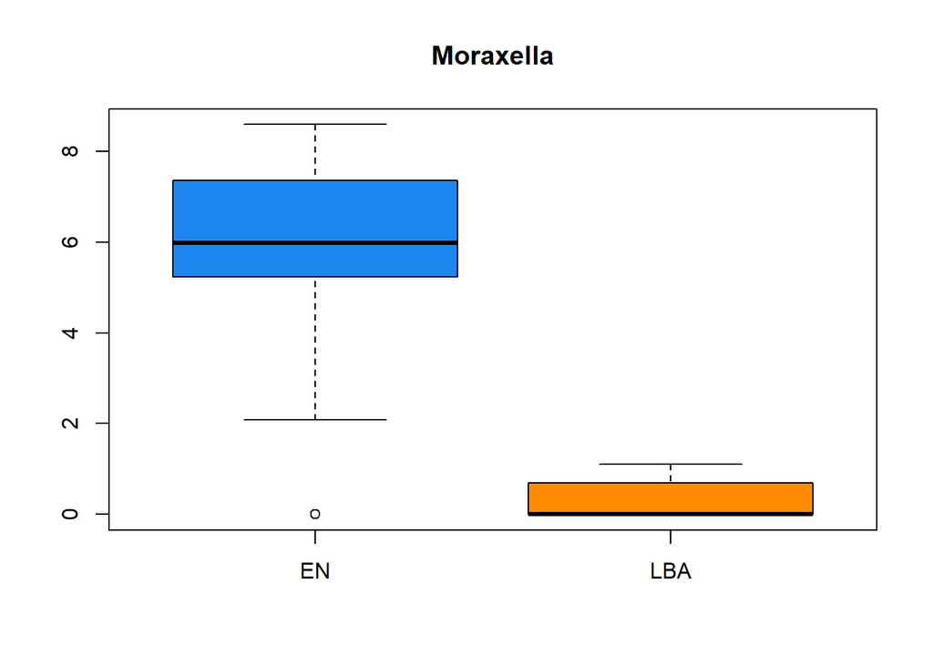

```r
boxplot(testEN,testLBA,names=c("EN","LBA"),
        main=selectVar(res_splsda, comp = 1)$name[3],col=c("dodgerblue2","darkorange"))
```

```r
testEN <- clean_log[clean_condition=="EN",which(selectVar(res_splsda, comp = 1)$name[4]==species)]
testLBA <- clean_log[clean_condition=="LBA",which(selectVar(res_splsda, comp = 1)$name[4]==species)]
t.test(testEN,testLBA,paired=TRUE)
```

```
##
##  Paired t-test
##
## data:  testEN and testLBA
## t = 12.382, df = 21, p-value = 4.077e-11
## alternative hypothesis: true difference in means is not equal to 0
## 95 percent confidence interval:
##  3.257027 4.571954
## sample estimates:
## mean of the differences
##                3.914491
```

We reject $H_0$ (the difference in means is equal to 0) hence we can say that there is a difference between the two types of samples (EN and LBA) for the Aquamicrobium bateria.

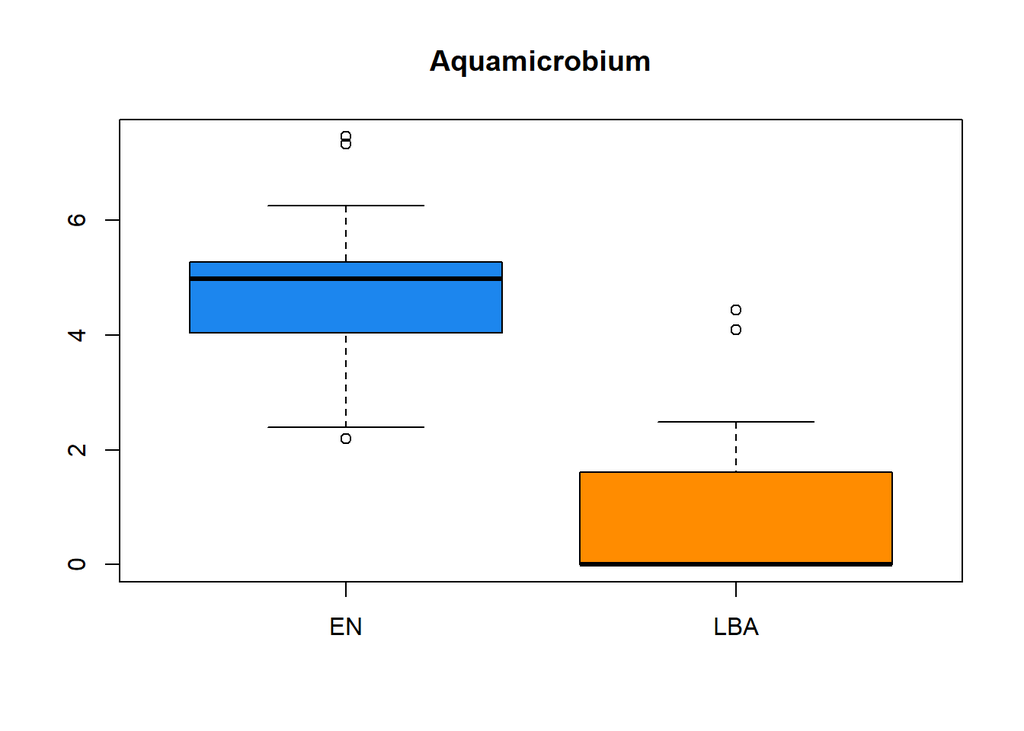

```r
boxplot(testEN,testLBA,names=c("EN","LBA"),
        main=selectVar(res_splsda, comp = 1)$name[4],col=c("dodgerblue2","darkorange"))
```

```r
testEN <- clean_log[clean_condition=="EN",which(selectVar(res_splsda, comp = 1)$name[5]==species)]
testLBA <- clean_log[clean_condition=="LBA",which(selectVar(res_splsda, comp = 1)$name[5]==species)]
t.test(testEN,testLBA,paired=TRUE)
```

```
##
##  Paired t-test
##
## data:  testEN and testLBA
## t = 12.319, df = 21, p-value = 4.484e-11
## alternative hypothesis: true difference in means is not equal to 0
## 95 percent confidence interval:
##  3.266202 4.592981
## sample estimates:
## mean of the differences
##                3.929592
```

We reject $H_0$ (the difference in means is equal to 0) hence we can say that there is a difference between the two types of samples (EN and LBA) for the Peptoclostridium bateria.

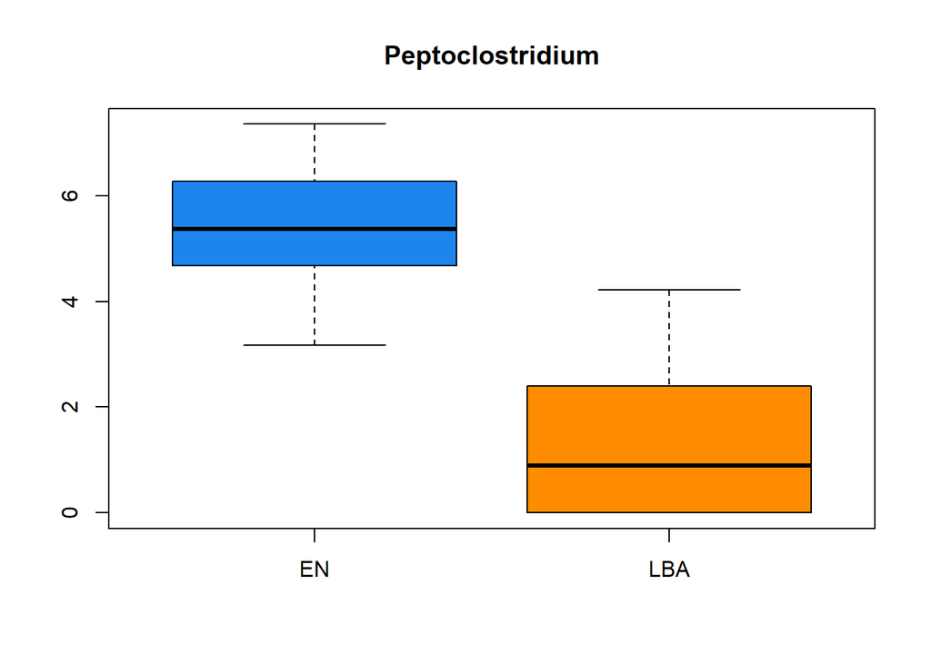

```r
boxplot(testEN,testLBA,names=c("EN","LBA"),
        main=selectVar(res_splsda, comp = 1)$name[5],col=c("dodgerblue2","darkorange"))
```

### with TSS+CLR transformation

```r
abundances_CLR <- data.frame(abundances_CLR)
names(abundances_CLR) <- species

set.seed(11)
res_plsda <- plsda(abundances_CLR, condition, ncomp = nlevels(condition))
res_perf <- perf(res_plsda, validation = 'Mfold', folds = 5,
                 progressBar = FALSE, nrepeat = 20)
plot(res_perf, overlay = 'measure', sd = TRUE)
plotIndiv(res_plsda , comp = c(1, 2), ind.names = FALSE, ellipse = TRUE,
          legend = TRUE, title = 'PLS-DA (CLR)')
```

```r
clean_CLR <- data.frame(abundances_CLR[id_abundances != "29", ])
names(clean_CLR) <- species

set.seed(33)
res_plsda <- tune.splsda(clean_CLR, clean_condition,
                         ncomp = nlevels(clean_condition),
                         multilevel = clean_id,
                         test.keepX = 1:20, validation = 'Mfold',
                         folds = 10, dist = 'mahalanobis.dist', nrepeat = 10,
                         progressBar = FALSE)

plot(res_plsda)

sel_keepX <- res_plsda$choice.keepX[1:2]
sel_keepX
```

```r
res_splsda <- splsda(clean_CLR, clean_condition,
                     ncomp = nlevels(clean_condition), multilevel = clean_id,
                     keepX = sel_keepX)

plotIndiv(res_splsda, comp = c(1,2), ind.names = FALSE, ellipse = TRUE,
          legend = TRUE, title = 'sPLS-DA (CLR)')
```

```r
plotLoadings(res_splsda, comp = 1, method = 'mean', contrib = 'max')
plotLoadings(res_splsda, comp = 2, method = 'mean', contrib = 'max')
```

### with CSS transformation

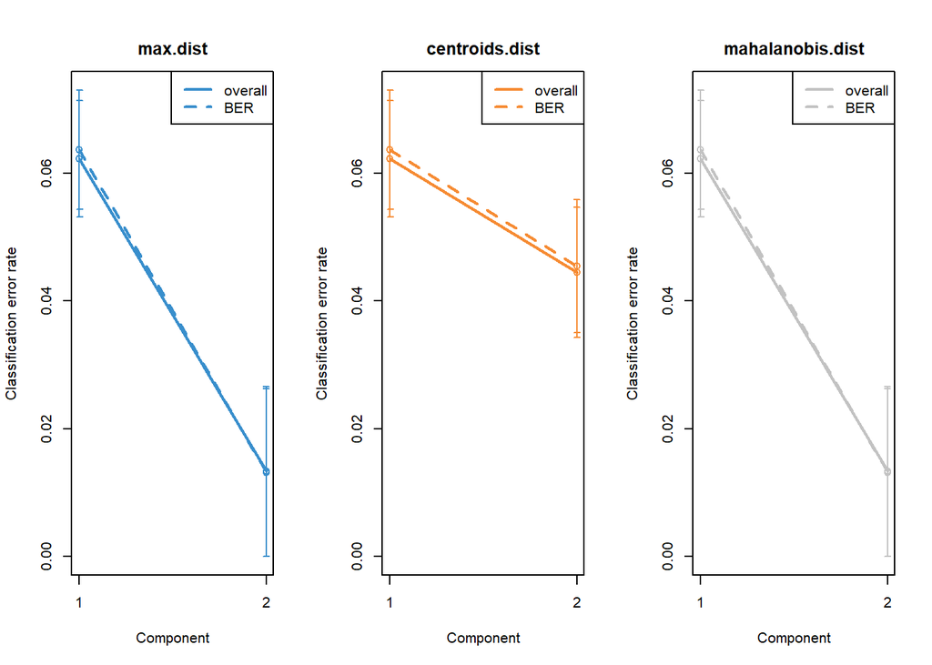

```r
abundances_CSS <- data.frame(t(log_CSS))
names(abundances_CSS) <- species

set.seed(11)
res_plsda <- plsda(abundances_CSS, condition, ncomp = nlevels(condition))
res_perf <- perf(res_plsda, validation = 'Mfold', folds = 5,
                 progressBar = FALSE, nrepeat = 20)
plot(res_perf, overlay = 'measure', sd = TRUE)
```

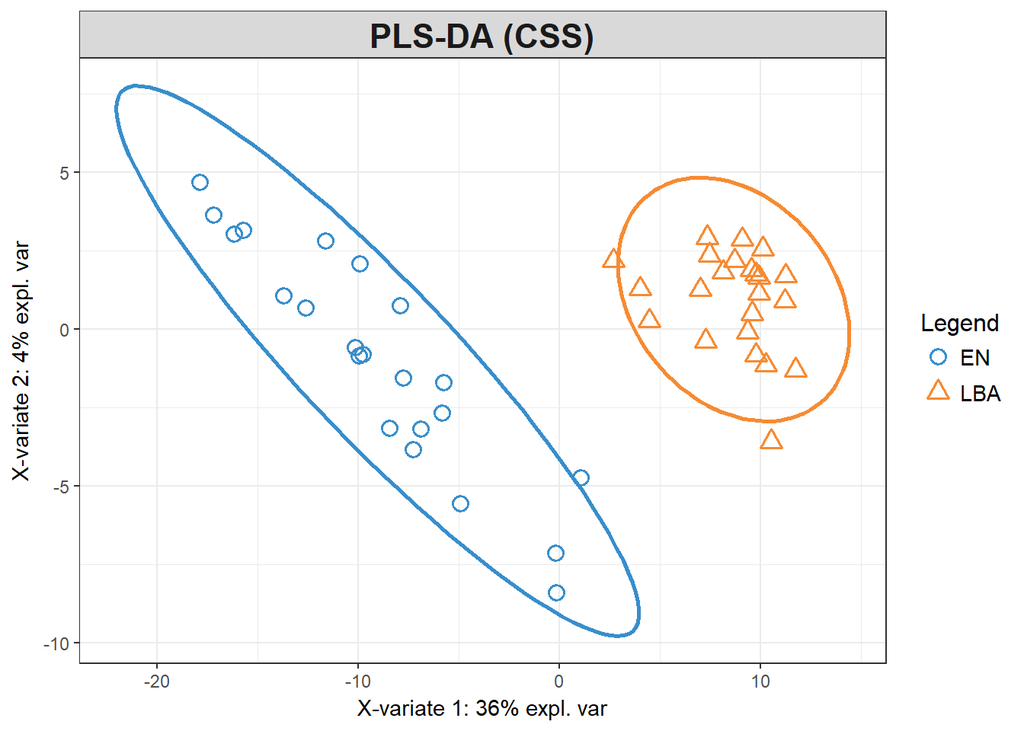

```r
plotIndiv(res_plsda , comp = c(1, 2), ind.names = FALSE, ellipse = TRUE,
          legend = TRUE, title = 'PLS-DA (CSS)')
```

```r
clean_CSS <- data.frame(abundances_CSS[id_abundances != "29", ])
names(clean_CSS) <- species

set.seed(33)
res_plsda <- tune.splsda(clean_CSS, clean_condition,
                         ncomp = nlevels(clean_condition),
                         multilevel = clean_id,
                         test.keepX = 1:20, validation = 'Mfold',
                         folds = 10, dist = 'mahalanobis.dist', nrepeat = 10,
                         progressBar = FALSE)
```

```
## Splitting the variation for 1 level factor.
```

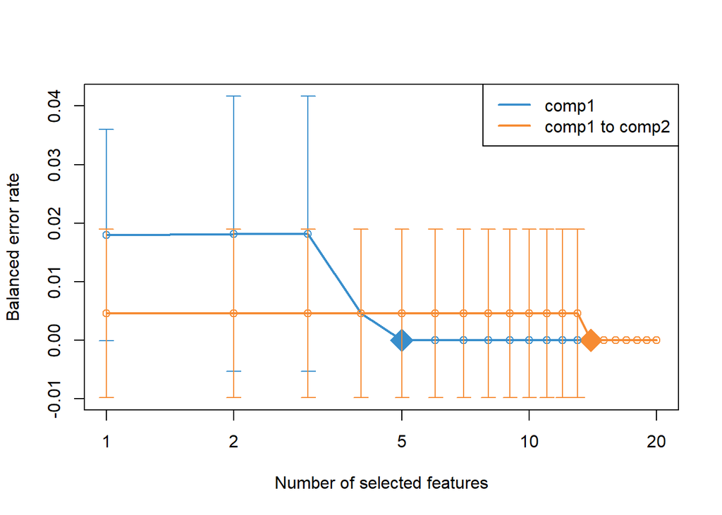

```r
plot(res_plsda)
```

```r
sel_keepX <- res_plsda$choice.keepX[1:2]
sel_keepX
```

```
## comp1 comp2
##     5    14
```

```r
res_splsda <- splsda(clean_CSS, clean_condition,
                     ncomp = nlevels(clean_condition), multilevel = clean_id,
                     keepX = sel_keepX)
```

```
## Splitting the variation for 1 level factor.
```

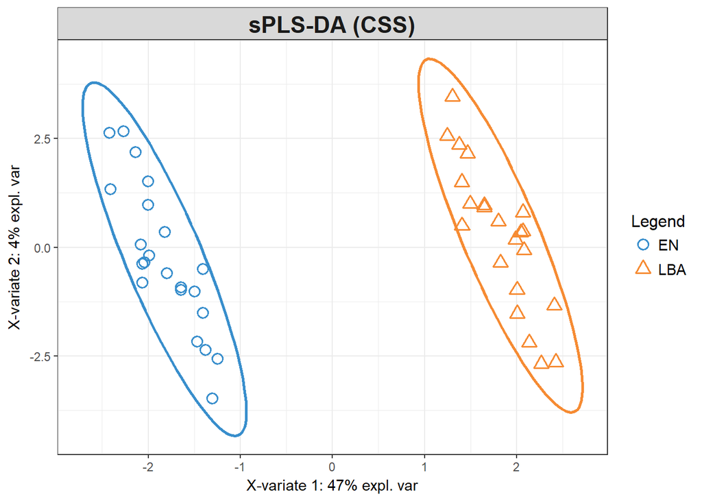

```r
plotIndiv(res_splsda, comp = c(1,2), ind.names = FALSE, ellipse = TRUE,
          legend = TRUE, title = 'sPLS-DA (CSS)')
```

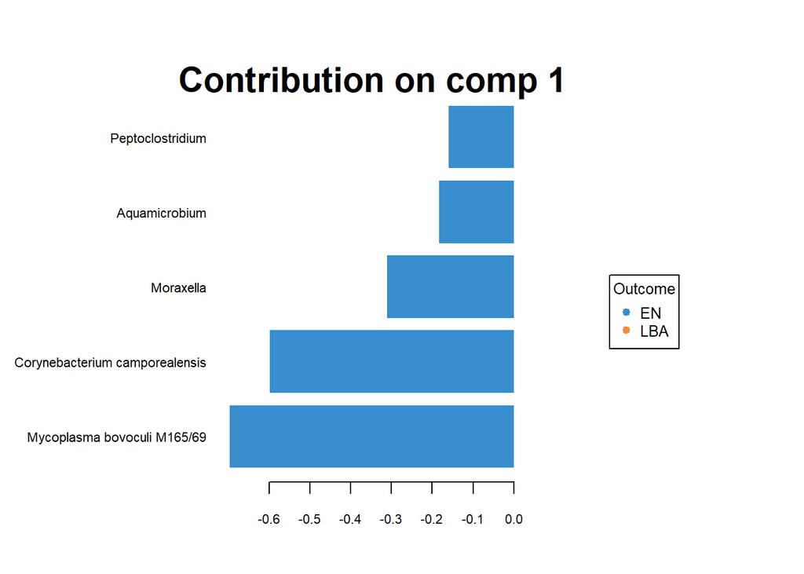

```r
plotLoadings(res_splsda, comp = 1, method = 'mean', contrib = 'max')
```

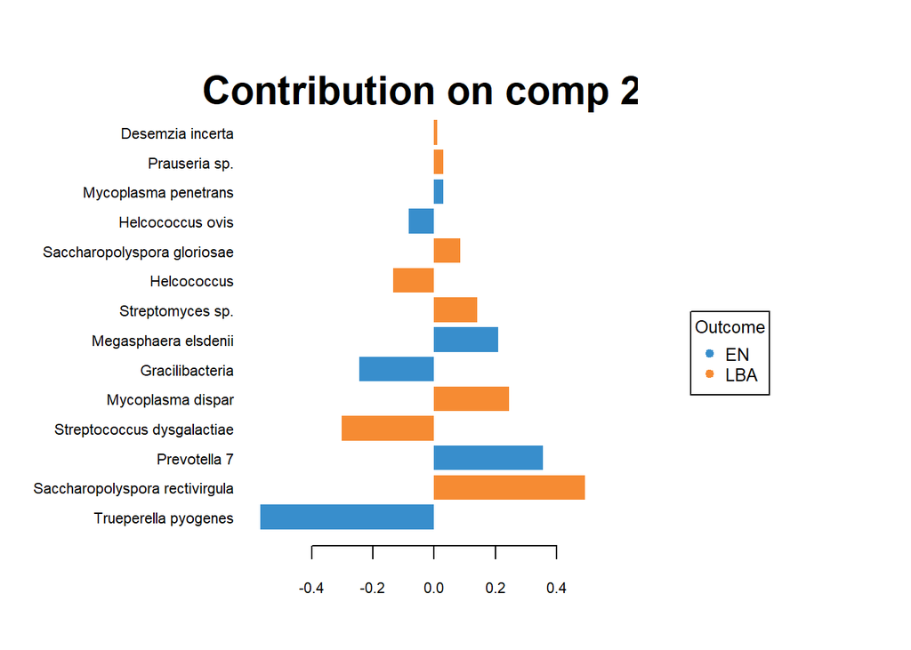

```r
plotLoadings(res_splsda, comp = 2, method = 'mean', contrib = 'max')
```